# 2026年度 E3 ネットワーク構築（電気電子工学実験Ⅲ後期）

2026-10-08

v0.2.0 / 2026-10-08

# 2026年度 E3 ネットワーク構築（電気電子工学実験Ⅲ後期）

嶋 直樹

概要説明スライド（参考・改訂前の版）

# 実験概要

## 1. 目的と進め方

2回の実験を通して、ペアごとのLANをルーターで接続し、静的ルーティング、DNS、NAPT、DHCPの働きを設定と観察から説明できるようになる。家庭や会社で、複数の端末がルーターを経由してWebサーバーに接続する仕組みを、閉じた模擬環境で学ぶ。

実施日程、班分け、担当機器はTeamsで確認する。実験は二人一組で行い、操作担当と記録担当を途中で交代し、両者が設定と確認を経験する。

| 回 | 実施する内容 | 残す記録 |
| --- | --- | --- |
| 第1回 | 配線、固定IP、静的ルーティング、内部DNS | 配線とIPの表、経路表、疎通・名前解決の結果 |
| 第2回 | GWのNAPT、外部Web接続、DHCP | 変換前後の通信、外部DNSの応答、DHCPの配布情報 |

## 2. 機器と接続

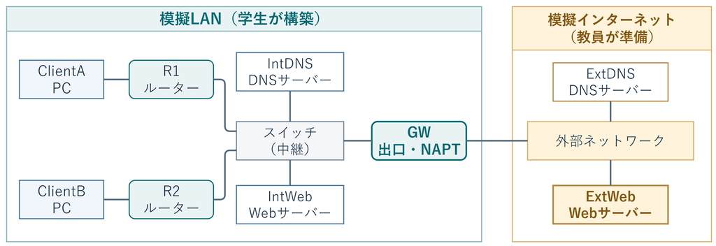

構成の概念図。R1・R2の2ペアを代表として示し、各ペア内のスイッチと2台目の端末、R3以降は省略している。共通のGW・DNS・Webは教員が準備する。

ルーターは異なるネットワークの間でパケットを中継する。スイッチは同じLAN内の端末を接続する。本実験では、ルーター用PCでネットワークOSのVyOSを動かす。

| 区域 | 接続する機器 | ネットワーク |
| --- | --- | --- |
| 模擬インターネット | GWの外側、外部DNS、外部Web | `10.0.0.0/24` |
| 共通ネットワーク | GWの内側、R1～R5の外側、共通DNS、共通Web | `192.168.1.0/24` |
| 各ペアのLAN | ペアルーターの内側、端末1・2 | `192.168.21.0/24`～`192.168.25.0/24` |

各ペアにはルーター用PC1台、Windows端末2台、専用スイッチ1台、LANケーブルを用意する。ルーターにはNIC（ネットワーク接続口）が2個必要である。外側を共通スイッチへ、内側をペア専用スイッチへ接続し、端末2台をペア専用スイッチにつなぐ。

ルーターの外側NICを`eth0`、内側NICを`eth1`と表記する。実際のNIC名とケーブルの対応は作業前に確認する。各ペアの内側LANは物理的に分ける。追加の6ペア目を使う場合はR6を接続する。

使用機器の割り当てはTeamsの案内に従う。下表はルーターごとの技術的な設定値を示す。共通GWは実験室のProxmox上のVM100（VyOS）を使う。共通・外部DNS、共通・外部Webの実行用機器は教員が準備する。

GWのeth0は模擬外部用の隔離された仮想LAN、eth1は実験室の共通スイッチに接続する。eth2は教員のSSH管理専用で、実験LANと学内LANの間の転送は許可しない。学生の設定には管理用アドレスを使わない。

## 3. IPアドレス割り当て

すべての接続はIPv4を使う。`/24`はサブネットマスク`255.255.255.0`を表す。以下の範囲では、先頭3組が同じIPアドレスは同じネットワークに属する。末尾`.0`はネットワークを表し、`.255`は一斉送信用なので端末に使わない。

### 共通機器

| 機器 | IPアドレス/マスク | デフォルトGW | DNS・役割 |
| --- | --- | --- | --- |
| GW 外側eth0 | `10.0.0.1/24` | 閉じた実験では不要 | 外部DNSは`10.0.0.53` |
| GW 内側eth1 | `192.168.1.1/24` | 同一機器の経路表に従う | 各ペアへの静的ルートを持つ |
| 共通DNS（IntDNS） | `192.168.1.53/24` | `192.168.1.1` | 内部名を応答、外部名を転送 |
| 共通Web（IntWeb） | `192.168.1.80/24` | `192.168.1.1` | DNSは`192.168.1.53` |
| 外部DNS（ExtDNS） | `10.0.0.53/24` | NAPT実験では不要 | 模擬外部名を応答 |
| 外部Web（ExtWeb） | `10.0.0.80/24` | NAPT実験では不要 | DNSは`10.0.0.53` |

`10.0.0.1`も`192.168.*.*`もプライベートアドレスである。外側のネットワークを「模擬インターネット」と呼ぶが、実インターネットに接続する必要はない。実在する公開DNS・WebのIPを模擬サーバーに割り当てない。[RFC 1918](https://www.rfc-editor.org/rfc/rfc1918.html)

### ペアルーター

| 名前 | 外側eth0（/24） | 内側eth1（/24） |
| --- | --- | --- |
| R1 | `192.168.1.21` | `192.168.21.1` |
| R2 | `192.168.1.22` | `192.168.22.1` |
| R3 | `192.168.1.23` | `192.168.23.1` |
| R4 | `192.168.1.24` | `192.168.24.1` |
| R5 | `192.168.1.25` | `192.168.25.1` |
| R6（追加用） | `192.168.1.26` | `192.168.26.1` |

全ペアルーターのデフォルトGWは`192.168.1.1`。DNSの転送先は`192.168.1.53`とする。予備機を故障機の代替に使う場合は、故障機を切り離してから対応するルーターの設定へ置き換える。

### 端末とDHCP

表の`N`はペア01なら21、02なら22、以降23～26である。`N`を含む表記をそのまま入力しない。

| 対象 | アドレス | ゲートウェイ・DNS |
| --- | --- | --- |
| 端末1（Web役兼用） | `192.168.N.10/24` | ともに`192.168.N.1` |
| 端末2（固定IP実験時） | `192.168.N.11/24` | ともに`192.168.N.1` |
| DHCP配布範囲 | `192.168.N.100`～`192.168.N.199` | ともに`192.168.N.1`を配布 |

端末はルーター用PCとは別の機器である。DSO01～10等の個別割り当ては開始時に確認する。端末2をDHCPに切り替えるとIPが変わるため、以降の確認には実際の配布アドレスを使う。

## 4. サービスと経路の方針

基本実験では、ペアルーターはアドレス変換を行わず、NAPTはGWの外側だけで行う。各ルーターにデフォルトルート、GWに各ペアLANへの戻り経路を設定する。

| DNS名 | IPアドレス | 用途 |
| --- | --- | --- |
| `common.lab.example` | `192.168.1.80` | 共通Web |
| `web.p01.lab.example` | `192.168.21.10` | ペア01のWeb |
| `web.p02.lab.example`～`web.p06.lab.example` | 対応するLANの末尾`.10` | 各ペアのWeb |
| `www.outside.example` | `10.0.0.80` | 外部Web |

WebはTCPポート8000で待ち受ける。DNS名は説明・実験に使う予約済みの`.example`配下とする。[RFC 2606](https://www.rfc-editor.org/rfc/rfc2606.html)

## 5. 教員の事前準備

1. VyOSの`show version`で版を確認する。以下の設定例はVyOS 1.5系の公式資料に基づく。実機が異なる版なら事前に構文を確認し、配布前に調整する。
2. GWと各ペアルーターのNIC名、配線、旧IP・旧NAT・旧DHCP設定を確認する。以下の手順は整理済みの実験用設定を前提とし、既存設定へ無条件に追記しない。
3. 共通・外部DNSとWebを割り当て表どおりに準備する。共通DNSには内部名のレコードと、`outside.example`を外部DNSへ転送する設定を用意する。外部DNSは`www.outside.example`を`10.0.0.80`として応答する。閉じた実験でこれらのゾーンを外部の公開DNSへ問い合わせない。
4. DNSの再帰・転送は実験用ネットワークから許可する。未署名の模擬ゾーンをDNSSEC検証で拒否しない実験用設定とする。WebのTCP/8000、DNSのUDP/TCP 53、疎通用ICMPを必要な範囲で許可する。ファイアウォール全体は無効にしない。
5. Windows端末で実験用有線LANのIPv4を設定できること、必要なアプリがインストール済みであることを確認する。実験中の通信がWi-FiやVPNへ迂回しないよう経路を整理する。
6. GWのNAPTは第2回の観察まで無効とし、外部DNS・Webには内部LANへの経路を入れない。GWと各ルーターの転送を有効にし、教員が事前に全経路を試験する。共通LAN内の同一NICへの転送や非対称経路を妨げるフィルター設定にも注意する。

2026年10月8日にGWの設定・保存と、仮の試験端末を使った経路・NAPT・学内LANへの転送遮断を確認済み。NAPTは第1回用に無効としている。共通・外部DNS/Webサーバーの構築と、学生が使う実機・配線を含む全体試験は別途必要である。

# 実験手順書：第1回 内部ネットワークと静的ルーティング

## 1. 操作する場所を確認する

Windowsの画面操作のようにボタンで操作する方法をGUI、文字で命令を入力する方法をCLIという。ターミナルは文字を入力・表示する画面、シェルは命令を解釈するプログラムである。

「Windows端末で実行」は手元のWindowsターミナルのPowerShellを指す。「VyOSで実行」はルーター本体のコンソールを指す。SSHでルーターへ接続している場合も、接続後のコマンドはルーター側で動く。手元をローカル、接続先をリモートと呼ぶ。

VyOSには確認用の運用モードと変更用の設定モードがある。

| 入力 | 意味 |
| --- | --- |
| `show interfaces` | 運用モードでNICとIPを確認 |
| `configure` | 設定モードに入る |
| `set ...` | 設定候補を追加・変更 |
| `compare` | 適用前の差分を確認 |
| `commit` | 設定を動作へ反映 |
| `save` | 再起動後も残すため保存 |
| `exit` | 設定モードを終了 |

設定モードで運用モードの確認コマンドを使う場合は、先頭に`run`を付ける。エラーが出たら次へ進まず、メッセージと実行場所を確認する。

以下はペア01（R1）の例である。ペア02～06は概要の表に従い、外側の末尾21とLAN番号21を、それぞれ22～26へ置き換える。共通GWの`192.168.1.1`と共通DNSの`192.168.1.53`は全ペア共通で変更しない。

## 2. 配線とルーターの設定

IPを変更するとSSH接続が切れる場合があるため、初期設定はルーター本体のコンソールで行う。共通スイッチからR1の外側、R1の内側からペア専用スイッチ、専用スイッチから端末2台へ配線する。NIC名・リンク状態を確認し、機器番号と接続口を実験ノートに記録する。

**R1・運用モードで確認：**

```
show version
show interfaces
show configuration commands
```

旧設定が残っている場合は教員に確認する。以下は教員が整理した初期設定に追加する例である。[VyOS Ethernet公式資料](https://docs.vyos.io/en/1.5/configuration/interfaces/ethernet.html)

**R1で設定：**

```
configure
set system host-name R1
set interfaces ethernet eth0 description COMMON
set interfaces ethernet eth0 address 192.168.1.21/24
set interfaces ethernet eth1 description PAIR01
set interfaces ethernet eth1 address 192.168.21.1/24
set protocols static route 0.0.0.0/0 next-hop 192.168.1.1
set system name-server 192.168.1.53
compare
commit
save
exit
```

`0.0.0.0/0`は、より具体的な経路がない宛先を表す。`next-hop`は次にパケットを渡す相手である。VyOSはルーターとして使うため、Ubuntu用の`sysctl`や`iptables`をここで実行しない。

## 3. Windows端末に固定IPを設定する

端末1は`192.168.21.10`、端末2は`192.168.21.11`とする。Windowsで`Win + R`を押し、`ncpa.cpl`を入力する。実験用の有線アダプターのプロパティから「インターネット プロトコル バージョン4（TCP/IPv4）」を開き、次を設定する。変更前の設定も記録しておく。

| 項目 | 端末1 | 端末2 |
| --- | --- | --- |
| IPアドレス | `192.168.21.10` | `192.168.21.11` |
| サブネットマスク | `255.255.255.0` | `255.255.255.0` |
| デフォルトゲートウェイ | `192.168.21.1` | `192.168.21.1` |
| 優先DNSサーバー | `192.168.21.1` | `192.168.21.1` |

代替DNSは設定せず、実験用DNSを通るようにする。WSL内部のアダプターではなく、ケーブルをつないだWindows側アダプターを設定する。

**端末1・PowerShellで確認：**

```powershell
ipconfig /all
ping -n 4 192.168.21.11
ping -n 4 192.168.21.1
```

`ping`は相手からの応答を確かめる命令、`-n 4`は4回試すというオプションである。同じLANの端末と、自分のルーターに応答があるか記録する。端末宛てだけ失敗する場合は、相手のファイアウォールで実験用ICMPが許可されているか教員と確認する。

## 4. 共通GWの経路設定（教員操作・全員で確認）

GWの内側は`192.168.1.1/24`、外側は`10.0.0.1/24`とする。GWには、各ペアLANへ戻る経路が必要である。[VyOS Static公式資料](https://docs.vyos.io/en/1.5/configuration/protocols/static.html)

**GWで設定：**

```
configure
set interfaces ethernet eth0 address 10.0.0.1/24
set interfaces ethernet eth1 address 192.168.1.1/24
set protocols static route 192.168.21.0/24 next-hop 192.168.1.21
set protocols static route 192.168.22.0/24 next-hop 192.168.1.22
set protocols static route 192.168.23.0/24 next-hop 192.168.1.23
set protocols static route 192.168.24.0/24 next-hop 192.168.1.24
set protocols static route 192.168.25.0/24 next-hop 192.168.1.25
compare
commit
save
exit
show ip route
```

R6を使う場合だけ、設定モードで`set protocols static route 192.168.26.0/24 next-hop 192.168.1.26`も追加する。閉じた模擬環境なので、GWに実在未確認の上流ルーターへのデフォルトルートは設定しない。この段階ではどのルーターでもNAPTを行わない。

## 5. 疎通と経路を調べる

**R1・運用モード：**

```
show ip route
ping 192.168.1.1 count 4
```

**ペア01の端末1・PowerShell：**

```powershell
ping -n 4 192.168.1.1
ping -n 4 192.168.1.80
ping -n 4 192.168.22.10
tracert -d 192.168.22.10
tracert -d 192.168.1.80
```

ペア02以外を相手にする場合は、そのペアの端末IPへ置き換える。相手ペアにも逆方向の確認を依頼し、両方の結果を保存する。`tracert -d`は途中のルーターをIPで表示する。途中に`*`が出ても、通信全体の失敗とは限らない。[Microsoft tracert](https://learn.microsoft.com/windows-server/administration/windows-commands/tracert)

| 通信 | 基本設定での往路 | 復路 |
| --- | --- | --- |
| ペア01 → ペア02 | 端末 → R1 → GW → R2 → 端末 | 逆順 |
| ペア01 → 共通Web | 端末 → R1 → 共通Web | 共通Web → GW → R1 → 端末 |

R1と共通Webは同じ共通ネットワークに直接接続されているため、共通Webへの往路はGWを通らない。ICMPリダイレクトなどによって観測経路が変わる場合もある。予想をそのまま結果とせず、実際の経路表・観察結果から説明する。

## 6. ペアルーターのDNS転送を設定する

DNSは名前に対応するIPアドレスを調べる仕組みである。各端末は自分のルーターへ問い合わせ、ルーターは共通DNSへ転送する。共通DNSの内部名レコードは教員が準備する。

**R1で設定：**

```
configure
set service dns forwarding listen-address 192.168.21.1
set service dns forwarding allow-from 192.168.21.0/24
set service dns forwarding name-server 192.168.1.53
set service dns forwarding dnssec off
compare
commit
save
exit
```

ここでは未署名の模擬ゾーンを扱う閉じた実験用にDNSSEC検証を無効にする。実運用のDNS設定とは区別する。問い合わせの受付は自分のLANに限定し、ペアルーター同士を相互の転送先にしない。[VyOS DNS Forwarding公式資料](https://docs.vyos.io/en/1.5/configuration/service/dns.html)

**端末1・PowerShell：**

```powershell
nslookup common.lab.example 192.168.21.1
nslookup web.p01.lab.example 192.168.21.1
```

それぞれ`192.168.1.80`と`192.168.21.10`が応答されるか確認する。DNSサーバー自身の逆引き名が「Unknown」でも、目的の名前への回答が正しいかで判断する。

ブラウザーで`http://common.lab.example:8000/`を開く。名前解決とWeb接続は別の処理なので、DNSが成功してもWebが表示されない場合は待受ポートやファイアウォールを確認する。

## 7. 記録と次回への保存

ペア番号、氏名、シール番号、NICの対応、端末IP、経路表、pingの応答数、経路追跡、DNSの回答を記録する。失敗時は、どこまで成功し、何を変更して改善したかを書く。最後にルーターで`save`を実行したことを確認する。共用GWの変更は教員が行い、各ペアが同時に編集しない。

# 実験手順書：第2回 NAPT・外部接続・DHCP

## 1. 前回の設定を確認する

端末から自分のルーター、共通GW、共通Web、他ペアの端末へIP指定で通信できることを確認する。名前指定の問題は、IP指定での通信を確認してから調べる。以下はペア01の例である。

**端末1・PowerShell：**

```powershell
ipconfig /all
ping -n 4 192.168.21.1
ping -n 4 192.168.1.80
nslookup common.lab.example 192.168.21.1
```

## 2. NAPT前の通信を観察する

教員はGWの外側が`10.0.0.1/24`で、外部Webが`10.0.0.80/24`であることを確認する。外部Webには内部LANへの静的ルートやデフォルトルートを設定しない。

**GW・運用モード：**

```
ping 10.0.0.80 count 4
```

**端末1・PowerShell：**

```powershell
ping -n 4 10.0.0.80
```

GW自身からは応答があり、端末からは応答がないという差を観察する。NAPT前の端末からのパケットは、送信元`192.168.21.10`のまま外部Webに届くが、外部Webには戻りの経路がない。失敗しただけでこの理由と断定せず、教員の経路確認やパケット観察と照合する。すでに成功する場合は、残存するNATや別の戻り経路を確認する。

## 3. GWでNAPTを設定する（教員操作・全員で確認）

NAPTは送信元のIPアドレスと、必要に応じてポート番号を変換する。GWの外側IPを複数の内部端末で共有し、対応表を使って応答を元の端末へ返す。本実験ではGWだけで行い、ペアルーターにはNAT設定を入れない。

GWには教員がルール100を無効状態で準備している。以下で設定内容を確認し、`disable`を削除して有効にする。

**GWで設定：**

```
configure
set nat source rule 100 description LAB-TO-OUTSIDE
set nat source rule 100 outbound-interface name eth0
set nat source rule 100 source address 192.168.0.0/16
set nat source rule 100 destination address 10.0.0.0/24
set nat source rule 100 translation address masquerade
delete nat source rule 100 disable
compare
commit
save
exit
```

この`192.168.0.0/16`は共通ネットワークと全ペアLANをまとめて照合する範囲であり、端末へ設定するサブネットマスクではない。端末は引き続き`/24`を使う。実験専用GWで、外側eth0から模擬外部ネットワークへ出る通信を対象にする。`masquerade`は出力NICのIP（ここでは`10.0.0.1`）へ変換する指定である。[VyOS NAT44公式資料](https://docs.vyos.io/en/1.5/configuration/nat/nat44.html)

次の班の第1回に戻すときは、教員が設定モードで`set nat source rule 100 disable`、`commit`、`save`を実行する。前の通信の接続状態を引き継がないよう、新しい接続でNAPT前後を観察する。

**端末1・PowerShell：**

```powershell
ping -n 4 10.0.0.80
```

ブラウザーで`http://10.0.0.80:8000/`を開く。NAPT前後の結果を記録する。応答がない場合は、GWの戻り経路と、外部Webの待受・ファイアウォールも確認する。NATの設定は、通信を許可するファイアウォール設定の代わりにはならない。

## 4. 外部DNSへの問い合わせを確認する

共通DNSは内部名を自ら回答し、`outside.example`への問い合わせを外部DNSの`10.0.0.53`へ転送する。これは教員が準備した設定を観察する実験である。

**端末1・PowerShell：**

```powershell
nslookup common.lab.example 192.168.21.1
nslookup www.outside.example 192.168.21.1
```

内部名は`192.168.1.80`、外部名は`10.0.0.80`と回答されるか確認し、`http://www.outside.example:8000/`を開く。

DNSの論理的な問い合わせ順序は「端末 → ペアルーターのDNS転送機能 → 共通DNS → 外部DNS」である。共通DNSから外部DNSへの通信はGWを通り、NAPTされる。キャッシュがあれば毎回すべての問い合わせが発生するとは限らない。

DNSが返すのは接続先のIPアドレスである。Webへの通信は名前解決後に別途行われ、DNSサーバーをWebの中継先として通過するわけではない。

## 5. 変換の対応を観察する

端末1・2から同じ外部Webを開く。教員はアクセス直後にGWの接続追跡表を表示し、全員で記録する。短い通信は表から消えるので、必要に応じてページを再読み込みする。

**GW・運用モード：**

```
show conntrack table ipv4
```

`Original src`は内部端末から始まる通信の送信元、`Original dst`は外部Web、`Reply src`は外部Web、`Reply dst`は外部Webから見た応答先である。NAPTしたWeb通信では、元の送信元が端末のIP、応答先がGWの外側IPになることを読み取る。表示形式は実機の版で確認する。[VyOS接続追跡の公式資料](https://docs.vyos.io/en/1.5/configuration/service/conntrack-sync.html#operation)

| 記録項目 | 端末1の通信 | 端末2の通信 |
| --- | --- | --- |
| 元の送信元IP・ポート | 実測値 | 実測値 |
| 外部WebのIP・ポート | 実測値 | 実測値 |
| 変換後の送信元IP・ポート（Reply dst） | 実測値 | 実測値 |

ポート番号が必ず変わるとは限らない。異なる内部端末の通信を区別できる対応が保持されていることに注目する。ICMPのpingにはTCP/UDPのポート番号がないため、Webのポートの観察と混同しない。

## 6. DHCPで端末2を自動設定する

DHCPは端末にIPアドレスやゲートウェイ、DNSを配布する仕組みである。配布は自分のLAN内だけで行い、固定IPの端末1と重複しない`.100`～`.199`を使う。

**R1で設定（VyOS 1.5系）：**

```
configure
set service dhcp-server shared-network-name PAIR01 subnet 192.168.21.0/24 subnet-id 21
set service dhcp-server shared-network-name PAIR01 subnet 192.168.21.0/24 option default-router 192.168.21.1
set service dhcp-server shared-network-name PAIR01 subnet 192.168.21.0/24 option name-server 192.168.21.1
set service dhcp-server shared-network-name PAIR01 subnet 192.168.21.0/24 range 0 start 192.168.21.100
set service dhcp-server shared-network-name PAIR01 subnet 192.168.21.0/24 range 0 stop 192.168.21.199
compare
commit
save
exit
```

ペア02以降は`PAIR01`とLAN番号・subnet-idを自分の番号に読み替える。この例は旧版の構文と混ぜず、教員が事前確認した版で実施する。[VyOS DHCP Server公式資料](https://docs.vyos.io/en/1.5/configuration/service/dhcp-server.html)

端末2の実験用有線アダプターのIPv4設定を、IP・DNSとも「自動的に取得する」へ変更する。端末1は固定IPのままとする。

**端末2・PowerShell：**

```powershell
ipconfig /all
```

IPが`.100`～`.199`、ゲートウェイとDNSが`192.168.21.1`であることを確認する。`169.254.*.*`ならDHCPでの取得に失敗している。配線、ルーターLAN側IP、DHCP設定を確認する。

**R1・運用モード：**

```
show dhcp server leases
```

端末2のMACアドレスと配布アドレスを照合する。端末2から共通Webと外部Webへの接続を再確認し、固定設定時との違いを記録する。

## 7. 発展：ペアの端末1でWebを公開する

教員がWindows用Pythonを準備している場合に実施する。以下はWindowsのPowerShellで実行し、WSLでは実行しない。専用フォルダーを作り、そのフォルダーの中身だけを公開する。

```powershell
New-Item -ItemType Directory -Force "$env:USERPROFILE\network-lab-web"
Set-Location "$env:USERPROFILE\network-lab-web"
Set-Content -LiteralPath index.html -Value '<h1>Pair 01</h1>' -Encoding utf8
python -m http.server 8000 --bind 192.168.21.10
```

`Set-Location`は作業するフォルダー（カレントディレクトリ）を移動する命令である。`python -m http.server`はそのフォルダーを公開する。見出しとIPは自分のペアに合わせる。実験用の既存`index.html`があれば、上書き前に内容を確認する。

教員が実験用ネットワークからのTCP/8000を許可したうえで、端末2から`http://192.168.21.10:8000/`、他ペアから`http://web.p01.lab.example:8000/`へ接続する。終了はサーバーを動かしたターミナルで`Ctrl + C`。この基本実験では静的ルーティングで到達するため、ペアルーターのNAPTやポート転送は追加しない。

## 8. 終了時の確認

設定と実測結果を保存する。GWの変更は教員が管理し、次期の実験前にNAPTの初期状態を戻す。端末のネットワーク設定と実験用ファイアウォール規則は、教員の指定する状態へ戻す。実インターネットへの接続、WSLのネットワーク変更、各ペアでのNAPT・ポート転送は今回の基本手順に含めない。

# レポート課題：実践的ネットワークシステムの構築

## 1. 課題の概要

2回にわたる「実践的ネットワークシステムの構築」実験で得られた結果と考察をレポートとしてまとめて提出せよ。このレポートは、実験を通して構築した多層的なネットワークに関する理解度を評価するためのものである。静的ルーティング、NAPT、DNSといった現代のネットワークを支える重要な技術要素について、自ら構築・確認した事実に基づいて論理的に説明する能力が求められる。

## 2. レポートの構成

以下の構成に従ってレポートを作成すること。

1. **表紙**
   - レポートタイトル、学科、学年、学生番号、氏名、Teamsで指定された実験グループの識別番号、提出日を明記すること。
2. **はじめに（目的）**
   - 本実験全体の目的（多層ネットワークの構築、ルーティング、NAPT、DNSの連携など）を、自分の言葉で簡潔にまとめること。
3. **実験環境**
   - 実験で構築した最終的なネットワーク構成図を自分で作成すること。共通GW、共通ネットワーク、自分と通信相手のペアLAN、模擬インターネットを区別すること。
   - 実験で使用したIPアドレス、NIC名、ルーター用PCの添付シール番号を表に記載すること。DHCPに切り替えた端末は配布後のIPも記録すること。
4. **実験手順と結果**
   - 各実験（第1回・第2回）の主要なステップについて、実行した内容と得られた結果を記述すること。
   - 特に、VyOSの`show ip route`、Windowsの`tracert -d`、GWのNAPT設定と`show conntrack table ipv4`、`nslookup`、DHCPの配布情報など、客観的な事実を正確に記録することを重視する。教員が操作したGWの結果には「教員実演を観察」と明記する。
   - 結果を示す際には、ターミナルの出力やGUIのスクリーンショットを適切に活用し、図や表を用いて分かりやすく整理すること。
5. **考察**
   - 実験結果に基づき、以下の問いに答えること。単に用語を調べるだけでなく、**実験のどの結果からそう言えるのか**を明確に示しながら論理的に考察を展開すること。

### 考察の問い

   - **問1:** 異なるペアの端末間で、パケットはどの経路を通ったか。例えばペア01の`192.168.21.10`からペア02の`192.168.22.10`への`tracert -d`と経路表を使って説明せよ。共通Web（`192.168.1.80`）への往路・復路とも比較し、GWを経由するかどうかを説明せよ。IPは実際に通信したペアの値を用いること。
   - **問2:** GWに自分のLANへの戻り経路がなく、代替経路もないとする。GWのNAPTが設定済みでも、端末から外部Web（`10.0.0.80`）への通信が成立しない理由を、「行き」「応答の逆変換」「戻りの経路選択」に分けて説明せよ。共用GWの経路を学生が勝手に削除せず、経路表を根拠に考察すること。
   - **問3:** 複数の端末がGWの外側IP（`10.0.0.1`）を共有して外部Webへ接続できる仕組みを、NAPT設定と接続追跡表を根拠に説明せよ。元の送信元・変換後の送信元・ポート番号を対応づけること。このIPは模擬環境のプライベートアドレスであり、グローバルIPとは呼ばない。
   - **問4:** `common.lab.example`と`www.outside.example`は、それぞれどのDNSが回答するか。端末、ペアルーターのDNS転送、共通DNS、外部DNSの役割を`nslookup`の結果と対応づけて説明せよ。DNSへの問い合わせと、その後のWebへの通信を区別すること。
   - **問5:** DHCPへ切り替えた端末のIP、サブネットマスク、ゲートウェイ、DNSはどうなったか。`ipconfig /all`とルーターのリース一覧を照合し、固定IPの端末1と重複しない理由を説明せよ。
6. **結論（まとめ）**
   - 実験全体を通して学んだこと、特に難しかった点やそれをどのように解決したか、さらに今後の学習で探求したいと感じた点などを自由に記述すること。
7. **参考文献（任意）**
   - レポート作成にあたり、参考にした書籍やWebサイトがあれば記載すること。

## 3. 評価基準

提出されたレポートは、以下のルーブリックに基づいて評価する。

| 評価項目 | A (優) | B (良) | C (可) | D (不可) |
| --- | --- | --- | --- | --- |
| **結果の記録の正確性と明瞭性** | コマンド出力や`tracert -d`の結果などが要点を押さえて整理され、誰が読んでも分かりやすく正確に記録されている。 | 結果は記録されているが、情報の整理が不十分であったり、説明が不足している点がある。 | 結果の記録に不足や誤りが多く、第三者が内容を再現することが困難である。 | 結果がほとんど記録されていない、または不正確である。 |
| **考察の論理性と深さ** | 各問いに対し、実験結果とネットワークの動作原理を関連付けた論理的で深い考察がなされている。 | 各問いに対し、実験結果に基づいた考察がなされているが、分析が表面的であったり、論理の飛躍が見られる。 | 考察が単なる用語説明に終始していたり、実験結果との関連性が薄い。 | 考察がほとんどなされていない、または見当違いである。 |
| **ネットワーク技術の統合的理解** | ルーティング、NAPT、DNSといった複数の技術が連携して一つのシステムとして動作している様子を統合的に理解し、説明できている。 | 各技術の個別の役割は理解しているが、それらの連携についての説明が不十分である。 | 技術の理解に根本的な誤りが多く見られる。 | ほとんど理解できていない。 |
| **問題解決能力** | 実験中に発生した問題に対し、原因を自ら切り分け、解決に至るプロセスがレポートから読み取れる。 | 問題の発生と結果は記述されているが、解決へのアプローチが不明確である。 | 問題解決の試みが見られない。 | 実験を完遂できていない。 |

## 4. 提出について

- **提出期限・提出方法:** Teamsの課題指示を確認すること。

# 補助資料：Windows・VyOSコマンド早見表

ペア01の例を示す。別のペアでは概要の割り当て表に読み替える。Windows端末用のコマンドとVyOS用のコマンドを混ぜない。

## Windows端末のPowerShell

| やりたいこと | コマンド・操作 |
| --- | --- |
| IP・ゲートウェイ・DNS・MACを確認 | `ipconfig /all` |
| 自分のルーターへ4回の疎通確認 | `ping -n 4 192.168.21.1` |
| 共通Webへ疎通確認 | `ping -n 4 192.168.1.80` |
| 他ペアまでの経路を確認 | `tracert -d 192.168.22.10` |
| Windowsの経路表を確認 | `route print -4` |
| 実験用DNSへ問い合わせ | `nslookup common.lab.example 192.168.21.1` |
| 外部Webの名前解決 | `nslookup www.outside.example 192.168.21.1` |
| ネットワークアダプター設定を開く | `Win + R` → `ncpa.cpl` |

`ping`の応答はIPで通信できた根拠であり、WebやDNSが動作する証拠とは別である。`tracert`の`*`はその途中の応答が得られなかったことを表し、直ちに通信全体の失敗を意味しない。

## VyOSの運用モード

| やりたいこと | コマンド |
| --- | --- |
| バージョンを確認 | `show version` |
| NICとIPを確認 | `show interfaces` |
| 経路表を確認 | `show ip route` |
| 現在の設定を確認 | `show configuration commands` |
| 共通GWへ疎通確認 | `ping 192.168.1.1 count 4` |
| DHCPの配布を確認 | `show dhcp server leases` |
| GWの接続追跡表を確認 | `show conntrack table ipv4` |

連続するコマンドの停止は`Ctrl + C`。表示が長い場合は必要な部分を保存し、ペア番号・日時・実行した機器名も記録する。

## VyOSの設定モード

```
configure
```

設定例を入力した後は、次の順で確認・反映・保存する。

```
compare
commit
save
exit
```

`commit`だけでは再起動後の保存にならない。設定モードで経路を確認するときは`run show ip route`と入力する。`set`で追記する前に旧設定を確認し、全設定やNAT表を一括削除しない。

## 接続できないときの確認順

1. ケーブル、リンク状態、NICの外側・内側の対応。
2. 端末のIP・マスク・ゲートウェイ。DHCPなら配布結果。
3. 自分のルーター、共通GW、目的のIPの順に疎通確認。
4. 往路と復路の経路表、必要な通信のファイアウォール許可。
5. 外部接続ならGWのNAPTと外部サーバーの状態。
6. IP指定で成功し名前指定だけ失敗するならDNS設定と回答。

基本手順ではUbuntuの`ip addr`・`iptables`・BIND9の設定コマンドをVyOSへ入力しない。旧原稿の`under_construction`内には異なる構成・版の例が残っているため、本指導書と混ぜない。